# Exploratory Report

Heyang Dai, Jinrui Fang, Jack Yue, Yachun Zhang, group: D2

2/27/2021

## Section 1. Problem Domain

COVID-19, as a global pandemic, has caused a significant impact on modern society in all aspects. Due to the COVID-19, almost every university in the United States has canceled the in-person courses, and the admission policies for first-year students have also changed a lot. For students in the university application season, the application for this year can be much more difficult. As an international student, it is not easy to collect information to choose and apply for a U.S. university. Under the pandemic, this situation can be even more challenging. Our purpose is to collect information on U.S. universities, including school rankings, school admission information, and policy changes response to COVID-19. While providing information to students, we also want to help students choose the university that suits them to apply.

##### Terminology define:

ipeds_id: The ID number of the college in the Integrated Postsecondary Education Data System (IPEDS).

fips: The Federal Information Processing Standards are a set of US Government security requirements for data and its encryption, which are shared and encouraged by the US Federal Government.

quality_of_education: rank for quality of education

quality_of_faculty: rank for quality of faculty

influence: rank for influence

citations: number of citations at the university

patents: number of patents overall

performance value: Sum of previous five factors divided by 5, the smaller value is, the better performance of the college is.

## Section 2. Data Description

The data set we used is from [Cwur](https://www.kaggle.com/gpreda/world-university-rankings-advanced-analysis). The Center for World University Rankings (CWUR) is a prominent organization and publisher of the one of the largest academic ranking of global universities and colleges. This data set covers three rankings’ systems across the world, the Times Higher Education World University Ranking, the Academic Ranking of World Universities, also known as the Shanghai Ranking, to The Center for World University Rankings. Myles O’Neill collected and made this data set available for us to access. At the top of the website, we could see he made this data set to make students investigate the best universities globally. This sample data set filters the ranking data for USA in the most recent year. It contains world ranking, national rank and score for institutions.

```
##    world_rank                           institution country national_rank
## 1           1                    Harvard University     USA             1
## 2           2                   Stanford University     USA             2
## 3           3 Massachusetts Institute of Technology     USA             3
## 4           6                   Columbia University     USA             4
## 5           7    University of California, Berkeley     USA             5
## 6           8                 University of Chicago     USA             6
## 7           9                  Princeton University     USA             7
## 8          10                    Cornell University     USA             8
## 9          11                       Yale University     USA             9
## 10         12    California Institute of Technology     USA            10
##     score
## 1  100.00
## 2   98.66
## 3   97.54
## 4   96.14
## 5   92.25
## 6   90.70
## 7   89.42
## 8   86.79
## 9   86.61
## 10  84.40
```

```
##                         College Private Apps Accept Enroll Outstate Room.Board
## 1  Abilene Christian University     Yes 1660   1232    721     7440       3300
## 2            Adelphi University     Yes 2186   1924    512    12280       6450
## 3                Adrian College     Yes 1428   1097    336    11250       3750
## 4           Agnes Scott College     Yes  417    349    137    12960       5450
## 5     Alaska Pacific University     Yes  193    146     55     7560       4120
## 6             Albertson College     Yes  587    479    158    13500       3335
## 7       Albertus Magnus College     Yes  353    340    103    13290       5720
## 8                Albion College     Yes 1899   1720    489    13868       4826
## 9              Albright College     Yes 1038    839    227    15595       4400
## 10    Alderson-Broaddus College     Yes  582    498    172    10468       3380
##    Grad.Rate Expend
## 1         60   7041
## 2         56  10527
## 3         54   8735
## 4         59  19016
## 5         15  10922
## 6         55   9727
## 7         63   8861
## 8         73  11487
## 9         80  11644
## 10        52   8991
```

The data set we used is from [Github](https://github.com/nytimes/covid-19-data/blob/master/colleges/colleges.csv). This dataset shows the counts of Covid-19 cases reported on college and university campuses in the United States.The author who created this dataset is Albert Sun. At this particular time, knowing the confirmed cases of COVID-19 at each school can help students make a better college choice because the number of confirmed cases is closely related to the students’ health. COVID-19 College Cases Dataset was created by New York Times, and they frequently updated this dataset, and the last version was updated on December 11th. In addition, this dataset attractBesidestion because it has a close relationship to all questions related to how COVID-19 affects colleges’ action in the U.S.The special term in this dataset: ipeds_id: The ID number of the college in the Integrated Postsecondary Education Data System (IPEDS). This sample data set shows number of covid cases in each college in the USA on latest day of data set.

```
##          date   state     county                            college cases
## 1  2020-12-11 Alabama    Madison             Alabama A&M University    41
## 2  2020-12-11 Alabama Montgomery           Alabama State University     2
## 3  2020-12-11 Alabama  Limestone            Athens State University    35
## 4  2020-12-11 Alabama        Lee                  Auburn University  2134
## 5  2020-12-11 Alabama Montgomery    Auburn University at Montgomery   140
## 6  2020-12-11 Alabama     Walker     Bevill State Community College     4
## 7  2020-12-11 Alabama  Jefferson        Birmingham-Southern College   214
## 8  2020-12-11 Alabama  Limestone          Calhoun Community College    84
## 9  2020-12-11 Alabama Tallapoosa  Central Alabama Community College    39
## 10 2020-12-11 Alabama     Coffee Enterprise State Community College    41
```

```
##          date      state cases
## 1  2020-01-21 Washington     1
## 2  2020-01-22 Washington     1
## 3  2020-01-23 Washington     1
## 4  2020-01-24   Illinois     1
## 5  2020-01-24 Washington     1
## 6  2020-01-25 California     1
## 7  2020-01-25   Illinois     1
## 8  2020-01-25 Washington     1
## 9  2020-01-26    Arizona     1
## 10 2020-01-26 California     2
```

### Subsection 2.2 Summary Analysis

### Summary Description Statistics

```
##    College            Private               Apps           Accept
##  Length:777         Length:777         Min.   :   81   Min.   :   72
##  Class :character   Class :character   1st Qu.:  776   1st Qu.:  604
##  Mode  :character   Mode  :character   Median : 1558   Median : 1110
##                                        Mean   : 3002   Mean   : 2019
##                                        3rd Qu.: 3624   3rd Qu.: 2424
##                                        Max.   :48094   Max.   :26330
##      Enroll       Top10perc       Top25perc      F.Undergrad
##  Min.   :  35   Min.   : 1.00   Min.   :  9.0   Min.   :  139
##  1st Qu.: 242   1st Qu.:15.00   1st Qu.: 41.0   1st Qu.:  992
##  Median : 434   Median :23.00   Median : 54.0   Median : 1707
##  Mean   : 780   Mean   :27.56   Mean   : 55.8   Mean   : 3700
##  3rd Qu.: 902   3rd Qu.:35.00   3rd Qu.: 69.0   3rd Qu.: 4005
##  Max.   :6392   Max.   :96.00   Max.   :100.0   Max.   :31643
##   P.Undergrad         Outstate       Room.Board       Books
##  Min.   :    1.0   Min.   : 2340   Min.   :1780   Min.   :  96.0
##  1st Qu.:   95.0   1st Qu.: 7320   1st Qu.:3597   1st Qu.: 470.0
##  Median :  353.0   Median : 9990   Median :4200   Median : 500.0
##  Mean   :  855.3   Mean   :10441   Mean   :4358   Mean   : 549.4
##  3rd Qu.:  967.0   3rd Qu.:12925   3rd Qu.:5050   3rd Qu.: 600.0
##  Max.   :21836.0   Max.   :21700   Max.   :8124   Max.   :2340.0
##     Personal         PhD            Terminal       S.F.Ratio
##  Min.   : 250   Min.   :  8.00   Min.   : 24.0   Min.   : 2.50
##  1st Qu.: 850   1st Qu.: 62.00   1st Qu.: 71.0   1st Qu.:11.50
##  Median :1200   Median : 75.00   Median : 82.0   Median :13.60
##  Mean   :1341   Mean   : 72.66   Mean   : 79.7   Mean   :14.09
##  3rd Qu.:1700   3rd Qu.: 85.00   3rd Qu.: 92.0   3rd Qu.:16.50
##  Max.   :6800   Max.   :103.00   Max.   :100.0   Max.   :39.80
##   perc.alumni        Expend        Grad.Rate
##  Min.   : 0.00   Min.   : 3186   Min.   : 10.00
##  1st Qu.:13.00   1st Qu.: 6751   1st Qu.: 53.00
##  Median :21.00   Median : 8377   Median : 65.00
##  Mean   :22.74   Mean   : 9660   Mean   : 65.46
##  3rd Qu.:31.00   3rd Qu.:10830   3rd Qu.: 78.00
##  Max.   :64.00   Max.   :56233   Max.   :118.00
```

In “college_df” dataset, we can know the enrollment information of each colleges in USA. We can find that the average number for the college to accept the students is 2018.804, and the median is 1110. However, the max number for the college to accept the students is 26330, which could be an outlier. The average graduation rate for us colleges is 65.463%. However, the max graduation rate is 118, which can be an outlier.

```
##      date              state              county              city
##  Length:1948        Length:1948        Length:1948        Length:1948
##  Class :character   Class :character   Class :character   Class :character
##  Mode  :character   Mode  :character   Mode  :character   Mode  :character
##
##
##
##
##     ipeds_id          college              cases           notes
##  Min.   :  100654   Length:1948        Min.   :   0.0   Length:1948
##  1st Qu.:  155367   Class :character   1st Qu.:  14.0   Class :character
##  Median :  190600   Mode  :character   Median :  54.0   Mode  :character
##  Mean   :  569751                      Mean   : 213.4
##  3rd Qu.:  219378                      3rd Qu.: 162.8
##  Max.   :49005401                      Max.   :5806.0
##  NA's   :1                             NA's   :70
```

In “us_college_cases” dataset, we can know the cumulated cases numbers for each college in each state and county on 2020-12-11. We can find the average number for us colleges cases is rounded to 213 studens, and the median for the cases is rounded to 54 students. The difference between mean and median is such large, which means that the data has a large degree of dispersion, and the overall trend is not obvious.

### States with highest COVID-19 Cases in the U.S.

This graph shows 4 states with highest COVID-19 cases and 4 states with lowest COVID-19 cases. I find one outlier in this plot, which has the state name of Northern Mariana Islands, and this outlier state has COVID-19 cases of 113.

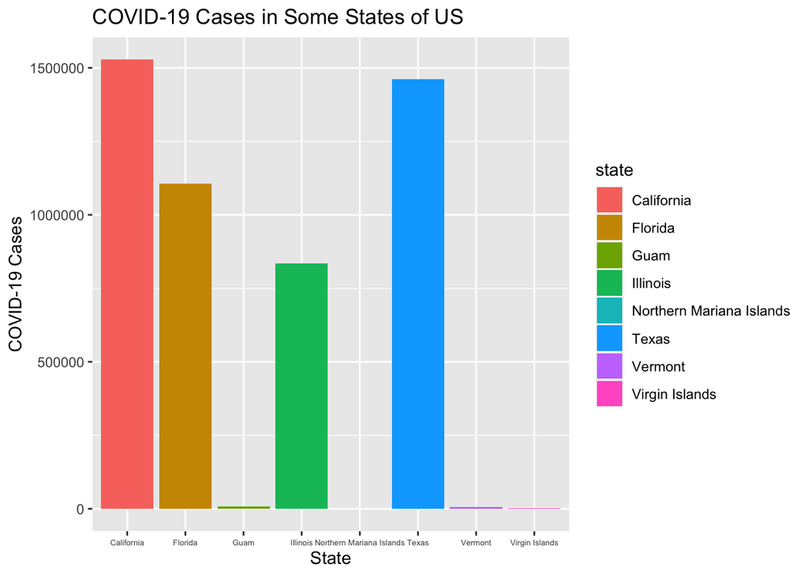

### Graduation and Acceptance Rate of Colleges in the U.S.

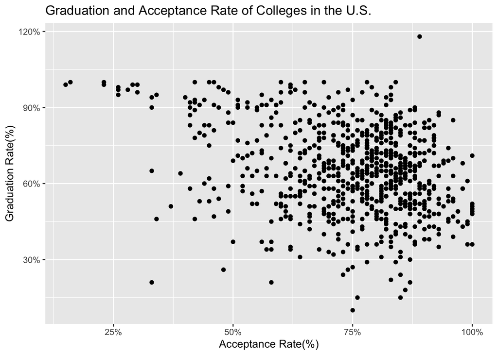

### Students of Cost and Spending in US Colleges

This graph is to compare the college total spending for outstate students in different colleges’ applications. By looking at the graph, we could tell that there two outliers. One is for extraordinary high college spending that Johns Hopkins University would spend “83313” dollars for college education fees.In addition, antoher outlier was that Rutgers at New Brunswick has extremely high applicattions, “48094” applications.

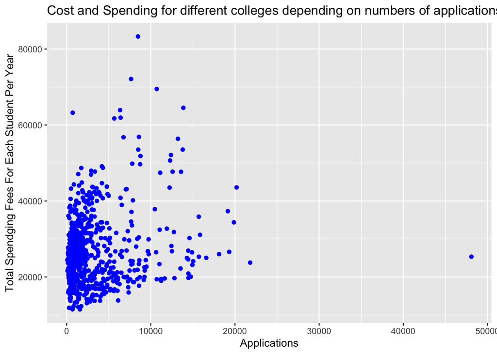

## Section 3: Specific Question Analyses

### Q1: Comparing the data of the private and public colleges? what kinds of information can I get in order to help the students make a better decision?

By comparing the information from each colleges, we can get lots of useful information in order to help us analysis each college.

At first, I need to split the data into two type, one is the pravite colleges, the other one is the public colleges. Then, I count the mean of the acceptance rate and expend of two types. In order to see the difference between private and public universities more intuitively, I made a plot which is able to see the distributions for each college.

This is my graph for the results of filtering the data into two types of college by comparing there acceptance rate and their expend

[figure not shown]

### Q2 : How are the factors on ranking US colleges?

In this section, the question is “How are the factors on ranking US colleges?” And we are going to analyze the total six factors influencing the rank of the colleges.

In order to show the clear and understandable graphs and table, we might take first top all universities with six factors including quality_of_faculty, quality_of_education, influence, citations, patents and overall performance value.

Note six factors are refered below: quality_of_education: rank for quality of education quality_of_faculty: rank for quality of faculty influence: rank for influence citations: number of citations at the university patents: number of patents overall performance value: Sum of previous five factors divided by 5, the smaller value is, the better performance of the college is

We will use mutate to define one new column to compare different colleges, since we know the meaning of the factors, so we might guess the small value of our value, the university would be better, and we will figure that out in my problem and giving the analysis on different colleges’ performances.

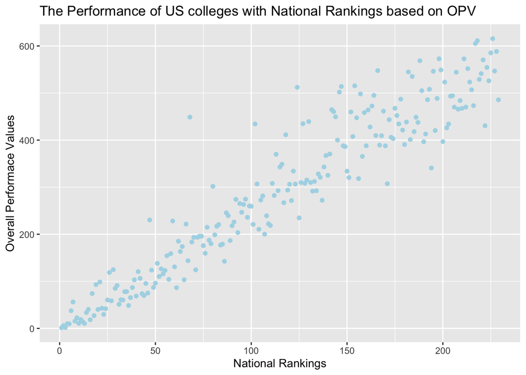

```
##          institution national_rank quality of education quality of faculty
## 1 Harvard University             1                    1                  1
##   influence citations patents overall_performace_value
## 1         1         1       3                      1.4
```

```
##          institution national_rank quality of education quality of faculty
## 1 Oakland University           226                  367                218
##   influence citations patents overall_performace_value
## 1       810       812     871                    615.6
```

```
##                     institution national_rank quality of education
## 1 Southern Methodist University            68                  179
##   quality of faculty influence citations patents overall_performace_value
## 1                218       655       368     824                    448.8
```

From the scatter plot, we can see the data in the plot have the positively tendency with the rankings, showing that the smaller value of the college had, the ranking of the college would be higher.

As a result, we got the best performance of college is Harvard University,in our defined value and the rest of these five factors are shown in the first table, Oakland University might have the most poor performance with five factors are shown in the second table.

Still, we found some outliers as well, like Southern Methodist University has extremely high value of OPV but rankings are still higher in our settings with five factors are shown in the third table.

As a result, we made the conclusion that, the variable that we defined “overall performance value” could show the performance in the general view and we could easily to see the rest of five factors influcing the rank of the colleges.

### Q3: What percentage of the number of college students diagnosed in each state accounted for the total number of diagnoses in the state?

In this section, we are going to use the data of cases from different US colleges comparing with the cases in different states, and find the ratio of cases for each college in its state. As a result, in this section, “cases” " states" and “college” can be the most consideration for answering problems.

We combined the useful lists of “us_college_cases” dataset and “us_cases_info” dataset and calculated the proportion of the number of cases in each school to the number of cases in the state.

We will use select() and filter() to select the specific data we want, we’ll also use mutate() to define one new colunm to compare the college cases ratio in different state. We will use the proportion of the number of cases of college students in each state to guess the risk of students contracting COVID-19 in each state because of going to college, and use this data to help students choose schools during the COVID-19 pandemic. Students may influence their choices through the risk of infection at the local colleges.

This is my bar for us college student cases ratio in each state.

[figure not shown]

```
## # A tibble: 1 x 4
##   State   College_Cases State_Cases College_Cases_Ratio
##   <chr>           <int>       <int>               <dbl>
## 1 Wyoming          2171       38785                5.60
```

```
## # A tibble: 1 x 4
##   State                    College_Cases State_Cases College_Cases_Ratio
##   <chr>                            <int>       <int>               <dbl>
## 1 Northern Mariana Islands             0         113                   0
```

From the data, we can get the average value for college students case ratio, which is 2.5954%, and the median value is 2.9966%. We can also know that the Wyoming State has the highest college cases ratio, which is 5.5975%, with 38785 COVID-19 cases in the state, only 2171 college students were confirmed. And Northern Mariana Islands has the lowest college cases ratio, which is 0%.

In general, the ratio of college students to the number of confirmed cases in the state is about 3%, which is actually maintained at a not very high level. Therefore, we can infer that the probability of young students being diagnosed with COVID-19 in the college is relatively low. At the same time, because many colleges arehaving online course during the COVID-19 pandemic, students can choose their dream college without worrying too much.

### Q4: Does state with higher total cases also have higher ratio of college students infected to the total number of infections in the state?

College students in the United States have also been significantly affected by the COVID-19, many of whom have been diagnosed. Therefore, in order to better understand the specific diagnosis situation of college students, I plan to explore the situation of college students during the pandemic period.

This is my graph for the results of showing the relationship between total COVID-19 cases and ratio of college students infected to the total number of infections in the state.

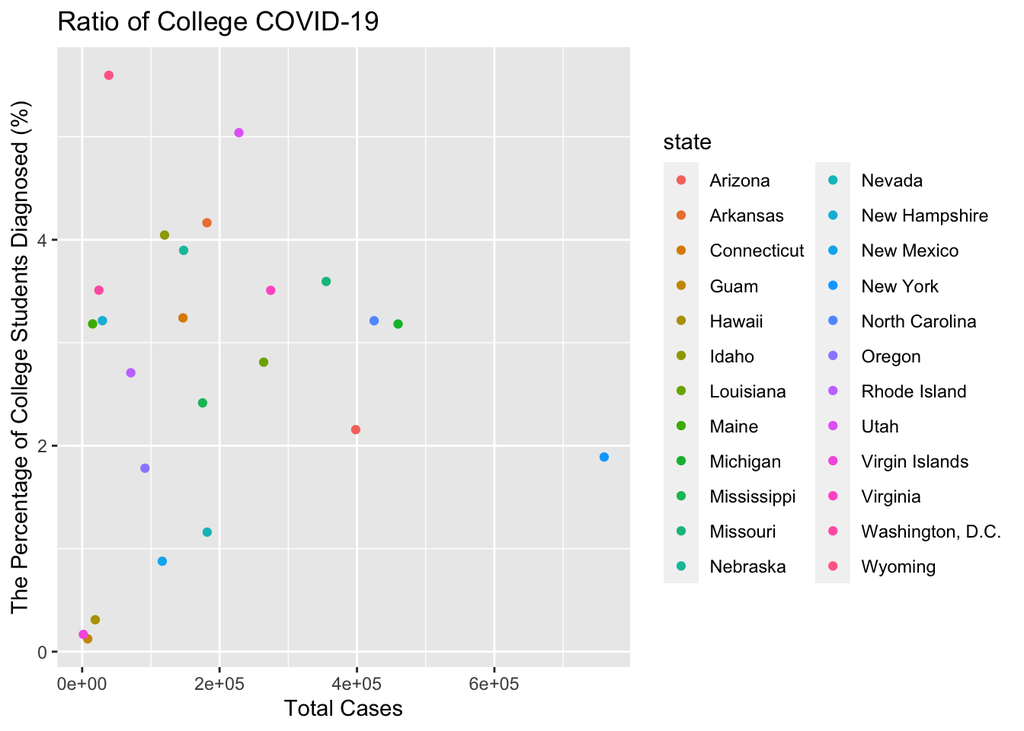